# project3

```python
import pandas as pd
import numpy as np
import matplotlib.pyplot as plt
%matplotlib inline
import seaborn as sns
```

```python
data =pd.read_csv('Churn Modeling.csv')
print(data.head())
```

```
   RowNumber  CustomerId   Surname  CreditScore Geography  Gender  Age  \
0          1    15634602  Hargrave          619    France  Female   42
1          2    15647311      Hill          608     Spain  Female   41
2          3    15619304      Onio          502    France  Female   42
3          4    15701354      Boni          699    France  Female   39
4          5    15737888  Mitchell          850     Spain  Female   43

   Tenure    Balance  NumOfProducts  HasCrCard  IsActiveMember  \
0       2       0.00              1          1               1
1       1   83807.86              1          0               1
2       8  159660.80              3          1               0
3       1       0.00              2          0               0
4       2  125510.82              1          1               1

   EstimatedSalary  Exited
0        101348.88       1
1        112542.58       0
2        113931.57       1
3         93826.63       0
4         79084.10       0
```

```python
#check data
print(f'The data has {data.shape[0]} rows and {data.shape[1]} features')
print(data.dtypes)
```

```
The data has 10000 rows and 14 features
RowNumber            int64
CustomerId           int64
Surname             object
CreditScore          int64
Geography           object
Gender              object
Age                  int64
Tenure               int64
Balance            float64
NumOfProducts        int64
HasCrCard            int64
IsActiveMember       int64
EstimatedSalary    float64
Exited               int64
dtype: object
```

```python
#drop irrelevant variables
data.drop(['RowNumber','CustomerId','Surname'], axis=1, inplace=True)
```

```python
#descriptive summary of the numerical features
print(data.describe())
```

```
        CreditScore           Age        Tenure        Balance  NumOfProducts  \
count  10000.000000  10000.000000  10000.000000   10000.000000   10000.000000
mean     650.528800     38.921800      5.012800   76485.889288       1.530200
std       96.653299     10.487806      2.892174   62397.405202       0.581654
min      350.000000     18.000000      0.000000       0.000000       1.000000
25%      584.000000     32.000000      3.000000       0.000000       1.000000
50%      652.000000     37.000000      5.000000   97198.540000       1.000000
75%      718.000000     44.000000      7.000000  127644.240000       2.000000
max      850.000000     92.000000     10.000000  250898.090000       4.000000

         HasCrCard  IsActiveMember  EstimatedSalary        Exited
count  10000.00000    10000.000000     10000.000000  10000.000000
mean       0.70550        0.515100    100090.239881      0.203700
std        0.45584        0.499797     57510.492818      0.402769
min        0.00000        0.000000        11.580000      0.000000
25%        0.00000        0.000000     51002.110000      0.000000
50%        1.00000        1.000000    100193.915000      0.000000
75%        1.00000        1.000000    149388.247500      0.000000
max        1.00000        1.000000    199992.480000      1.000000
```

```python
data.columns=data.columns.str.lower()
data.columns
```

```
Index(['creditscore', 'geography', 'gender', 'age', 'tenure', 'balance',
       'numofproducts', 'hascrcard', 'isactivemember', 'estimatedsalary',
       'exited'],
      dtype='object')
```

# Data Structure

### Main features of interest

I'm interested in determing what features predic customer churn.

### Features that would support investigation

I expect that bank balance, credit score, age,number of products, and estimated salary to have strong effect on churn. while gender, and tenure have little to no effect on exiting.

## Univariate Exploration

### How is account balance distributed in the client base?

Understanding balance distribution will guide the direction of this investigation since from a business perspective this is an important factor in identifying churning clients.

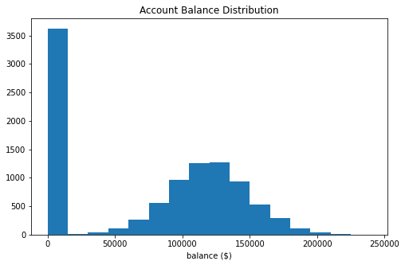

```python
#sns.set_style('darkgrid')
plt.figure(figsize=[8, 5])
binsize=15000
bins=np.arange(0, data['balance'].max()+1000, binsize)
plt.hist(data=data,x='balance', bins=bins);
plt.xlabel('balance ($)');
plt.title('Account Balance Distribution');
```

Account balance is bimodal distribution with the highest peak at 0.00, and the second distribution is a normal distribution with a peak between 100k and 150k.

## How is credit score distributed in the client base?

```python
 data['creditscore'].median()
```

```
652.0
```

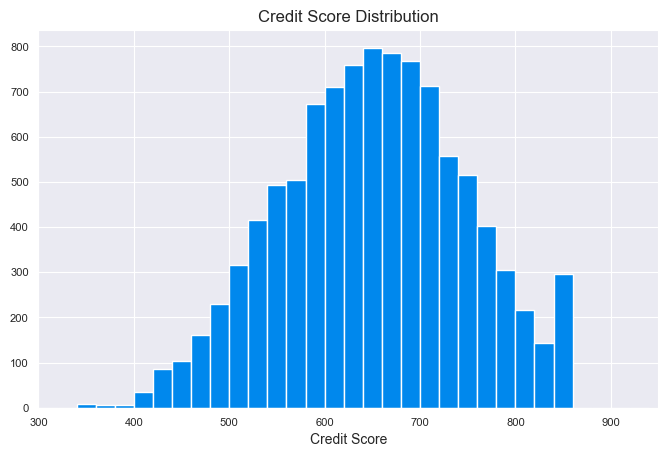

```python
#sns.set_style('darkgrid')
plt.figure(figsize=[8, 5])
binsize=20
bins=np.arange(0, data['creditscore'].max()+100, binsize)
plt.hist(data=data,x='creditscore', bins=bins);
plt.xlim(300, 950)
plt.xlabel('Credit Score');
plt.title('Credit Score Distribution');
```

Credit score follow unimodal normal distribution though slightly skewed to the left. Most clients have a credit score ranging between 580 and 720, not too far from the median credit score.

### How is estimated salary distributed in the data?

understanding income distribution for the clients deem useful especially when crafting target ads, and products.

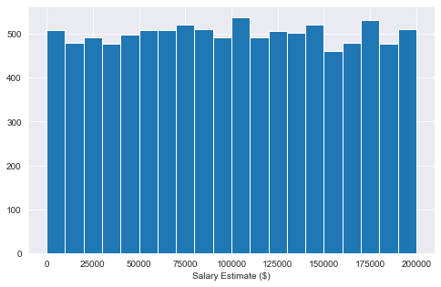

```python
#sns.set_style('darkgrid')
plt.figure(figsize=[8, 5])
binsize=10000
bins=np.arange(0, data['estimatedsalary'].max()+1000, binsize)
plt.hist(data=data,x='estimatedsalary', bins=bins);
#plt.xlim(0, 230000)
plt.xlabel('Salary Estimate ($)');
```

The distribution does not provide useful information in its current state

### Can we get useful information from scaled salary estimate?

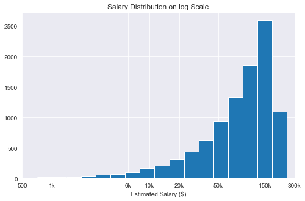

```python
#plot on log scale
log_binsize = 0.15
bins =10** np.arange(0, np.log10(data['estimatedsalary'].max())+log_binsize, log_binsize)

plt.figure(figsize=[8, 5])
plt.hist(data = data, x = 'estimatedsalary', bins = bins)
plt.xscale('log')
plt.xticks([5e2,1e3, 6e3,10e3,20e3, 50e3,150e3,300e3], ['500','1k', '6k', '10k','20k', '50k','150k','300k'])
plt.xlim(5e2, 300e3)
plt.xlabel('Estimated Salary ($)')
plt.title('Salary Distribution on log Scale')
plt.show()
```

Estimated salary has a long tail on the left in it's distribution with large proportion of salaries on the highest end, and few on the lowest end.

### How is age distributed in the data?

This information could help the bank understand the different age groups in their client base.

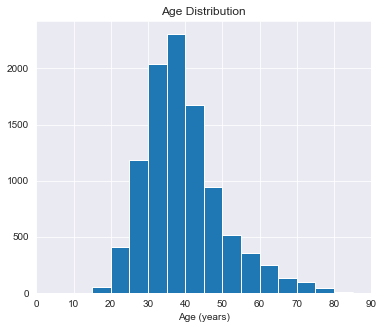

```python
#sns.set_style('darkgrid')
plt.figure(figsize=[6, 5])
binsize=5
bins=np.arange(0, data['age'].max()+10, binsize)
plt.hist(data=data,x='age', bins=bins);
plt.xlim(0, 90)
plt.xlabel('Age (years)');
plt.title('Age Distribution');
```

Age distribution is a unimodal normal distribution with a long tail on the right. The highest spikes are at between age 30 and 40. There are few clients above 50 years and below 20 years.

### How many clients own specific number of products?

This is important in creating customer segments. The bank could further investigate what products are purchased together and capitalize on this information in generating more profits and retaining existing clients.

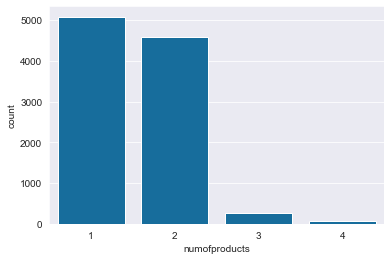

```python
sns.set_style('darkgrid')
color=sns.color_palette(palette='colorblind', n_colors=1)
sns.countplot(data=data,x='numofproducts', palette=color);
```

Generally most of the clients have one or two products. Very few clients have 3 or 4 products with the bank.

### How many men and women do we have in the client base?

This could be useful when designing product tailored for specific gender

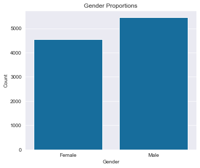

```python
sns.set_style('darkgrid')
color=sns.color_palette(palette='colorblind', n_colors=1)
plt.figure(figsize=[6, 5])
sns.countplot(data=data,x='gender', palette=color);
plt.title('Gender Proportions')
plt.xlabel('Gender', size=10)
plt.ylabel('Count', size=10);
```

There are more male than female clients in the bank's client base.

### What proportion owns credit card ?

Credit card is a profit generating tool for the bank, identifying these proportions could help the bank make critical decisions. If those who do not own card are way more than those who have card, the bank could investigate why and perhaps come up with deals/promos to attract more card owners from the existing client base.

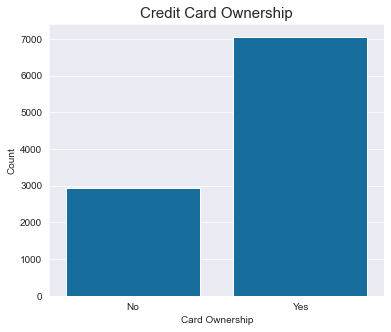

```python
sns.set_style('darkgrid')
color=sns.color_palette(palette='colorblind', n_colors=1)
plt.figure(figsize=[6, 5])
sns.countplot(data=data,x='hascrcard', palette=color);
plt.title('Credit Card Ownership',size=15)
plt.xlabel('Card Ownership', size=10)
plt.xticks([0,1], ['No', 'Yes'])
plt.ylabel('Count', size=10);
```

A large proportion of the clients has credit card.

### what proportion of the client base churned out?

identifying proportion of churned clients could give useful such that the bank can compare this proportion with their set threshhold for churn. This could be used as performance indicator as churn proportion below set threshold could signal poor performance, loss etc

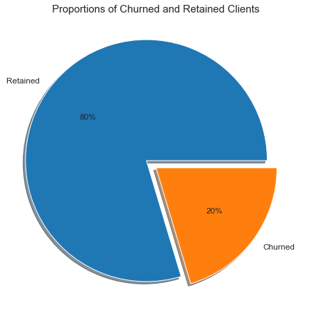

```python
churn=data['exited']
labs={0:'Retained', 1:'Churned'}
props=churn.value_counts().index.map(labs)
explode=(0.1,0)
plt.gcf().set_size_inches(18, 8)
churn.value_counts().plot(kind='pie',ylabel='',labels=props ,autopct='%.0f%%',textprops={'size': 'large'},shadow=True,explode=explode);
plt.title('Proportions of Churned and Retained Clients', size=15)
plt.show()
```

20 percent of the client base quit business with the bank and 80% are still doing business with the bank.

### What proportion of the clients is dormant?

This can tell the financial health status of the client base.

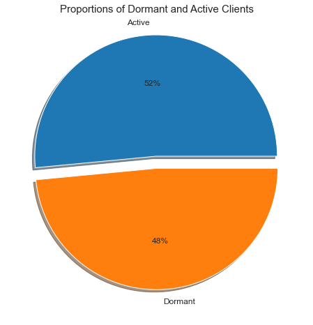

```python
active=data['isactivemember']
labs={0:'Dormant', 1:'Active'}
props=active.value_counts().index.map(labs)
explode=(0.1,0)
plt.gcf().set_size_inches(18, 8)
active.value_counts().plot(kind='pie',ylabel='',labels=props ,autopct='%.0f%%',textprops={'size': 'large'},shadow=True,explode=explode);
plt.title('Proportions of Dormant and Active Clients', size=15)
plt.show()
```

The proportion of active and dormant members is almost equal, too close.

# Bivariate Analysis

```python
print(data.columns)
```

```
Index(['creditscore', 'geography', 'gender', 'age', 'tenure', 'balance',
       'numofproducts', 'hascrcard', 'isactivemember', 'estimatedsalary',
       'exited'],
      dtype='object')
```

### Is there any correlation between numerical variables ?

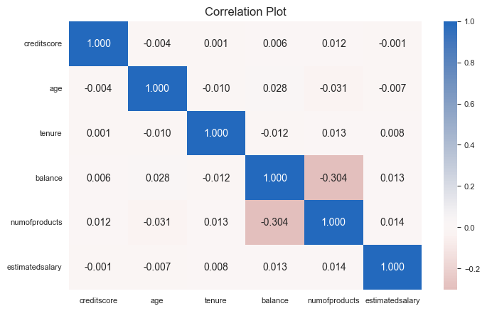

```python
cat_vars=['geography','gender','hascrcard','isactivemember','exited']
num_vars=['creditscore','age','tenure','balance','numofproducts','estimatedsalary']


plt.figure(figsize=[8,5])
sns.heatmap(data=data[num_vars].corr(), annot=True, fmt='.3f', center=0, cmap='vlag_r');
plt.title('Correlation Plot');
```

There is weak negative correlation between number of products and balance. No significant correlation between variables.

### How is the client base distributed by number of products and churn status?

The bank can easily identify churning clients by looking at the number of products clients own. Perhaps dig deep to understand what products such clients purchased.

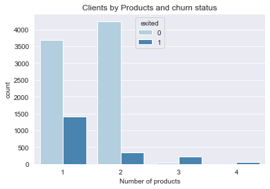

```python
sns.countplot(data=data, x='numofproducts',hue='exited', palette='Blues');
plt.xlabel('Number of products')
plt.title('Clients by Products and churn status');
```

## What is the mean account balance for churned and retained clients?

With the information the bank could easily identify what clients are most likely to churn out and come up with a strategy to retain such clients.

```python
churn=data.groupby('exited')['balance'].mean()
print(churn)
```

```
exited
0    72745.296779
1    91108.539337
Name: balance, dtype: float64
```

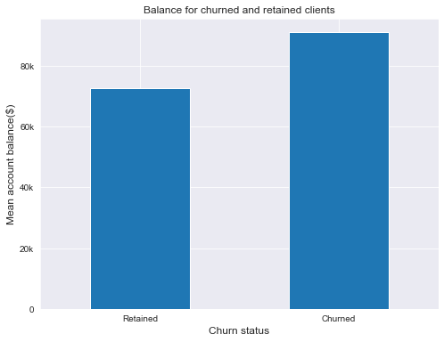

```python
plt.figure(figsize=(8,6))
churn.plot(kind='bar')
plt.xticks([0,1],['Retained','Churned'], rotation=0)
plt.yticks([0, 20e3,40e3,60e3,80e3], [0,'20k','40k','60k','80k'])
plt.title('Balance for churned and retained clients')
plt.xlabel('Churn status', size=12)
plt.ylabel('Mean account balance($)',size=12)
plt.show()
```

The average account balance for retained clients is lower than that of churned clients.

### What is the mean account balance for active and dormant members?

identifying account balance for both active and dormant clients could give information on whether to entice dormant clients with attractive deals or not depending on account balance.

```python
active=data.groupby('isactivemember')['balance'].mean()
print(active)
```

```
isactivemember
0    77134.376863
1    75875.422145
Name: balance, dtype: float64
```

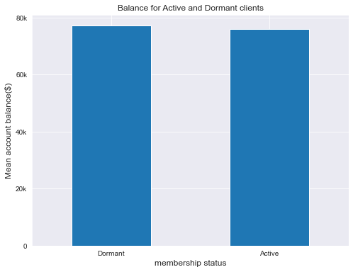

```python
plt.figure(figsize=(8,6))
active.plot(kind='bar')
plt.xticks([0,1],['Dormant','Active'], rotation=0)
plt.yticks([0, 20e3,40e3,60e3,80e3], [0,'20k','40k','60k','80k'])
plt.title('Balance for Active and Dormant clients')
plt.xlabel('membership status', size=12)
plt.ylabel('Mean account balance($)',size=12)
plt.show()
```

Average account balance for active and dormant clients is approximately equal.

### How does churn status, and number of products interact with balance, estimated balance and age?

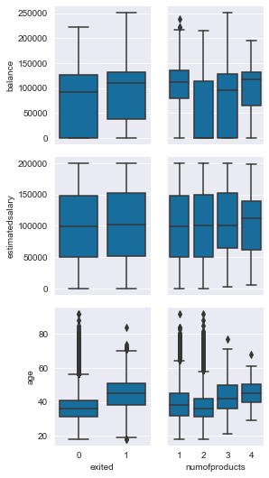

```python
plt.figure(figsize=(8,8))
g=sns.PairGrid(data=data, x_vars=['exited', 'numofproducts'],
               y_vars=['balance','estimatedsalary','age' ], palette=color,
              aspect=0.8)
g.map(sns.boxplot);
```

churned clients have higher account balance than retained clients. Besides, clients with two products have the lowest account balance while clients with 4 or 1 products have the highest balance followed by clients with 3 products.

Estimated Salary: clients with 1,2,3 products have approximately equal salary estimate. Clients with 4 products have the highest salary estimate. Salary estimate for both churned and retained clients is approximately equal about 100k. Estimated salary does not provide useful information to my investigation so I will drop it.

### How is age, and balance distributed by churn status and number of products?

compared to box plot above, Violin plot could cleary show how balance and age is distributed by churn status and number of products.

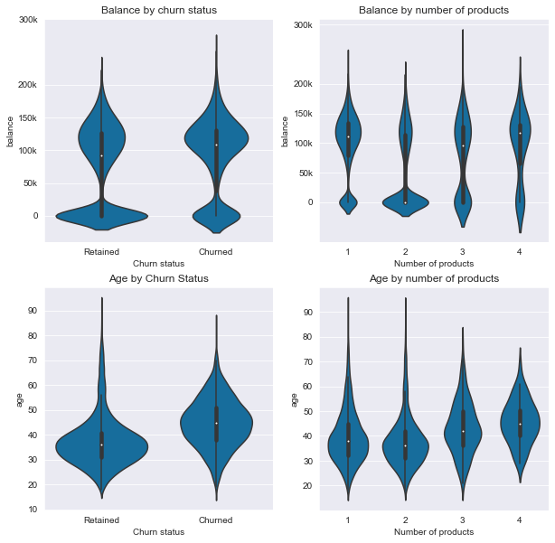

```python
fig, ax=plt.subplots(nrows=2, ncols=2, figsize=(10,10))
sns.violinplot(data=data, y='balance', x='exited',ax=ax[0,0], palette=color)
ax[0,0].set_yticks([0, 5e4,100e3,150e3,200e3, 300e3]);
ax[0,0].set_xticks([0,1],['Retained', 'Churned'])
ax[0,0].set_yticklabels([0, '50k','100k','150k','200k', '300k']);
ax[0,0].set_title('Balance by churn status')
ax[0,0].set_xlabel('Churn status')

sns.violinplot(data=data, y='balance', x='numofproducts',ax=ax[0,1],palette=color)
ax[0,1].set_yticks([0, 5e4,100e3,150e3,200e3, 300e3]);
ax[0,1].set_yticklabels([0, '50k','100k','150k','200k', '300k']);
ax[0,1].set_title('Balance by number of products')
ax[0,1].set_title('Balance by number of products')
ax[0,1].set_xlabel('Number of products')

sns.violinplot(data=data, y='age',x='exited', ax=ax[1,0],palette=color);
ax[1,0].set_title('Age by Churn Status')
ax[1,0].set_xticks([0,1],['Retained', 'Churned'])
ax[1,0].set_xlabel('Churn status')
sns.violinplot(data=data, y='age',x='numofproducts', ax=ax[1,1],palette=color);
ax[1,1].set_title('Age by number of products')
ax[1,1].set_xlabel('Number of products')
plt.show()
```

### What is the mean account balance by number of products and churn status?

it is important to identify account balance of churned and retained clients. Also identifying interaction between churn account balance and number of products could help.

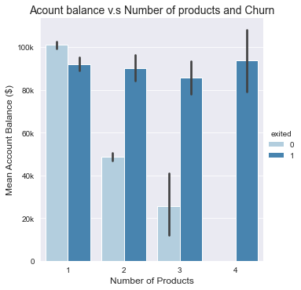

```python
sns.catplot(data=data, y='balance', x='numofproducts',hue='exited', kind='bar', palette='Blues')
plt.ylabel('Mean Account Balance ($)', size=12)
plt.xlabel('Number of Products', size=12)
plt.yticks([0, 20e3,40e3,60e3,80e3,100e3], [0,'20k','40k','60k','80k','100k'])
plt.title('Acount balance v.s Number of products and Churn', size=14);
```

### What is the average age by number of products and churn status?

If the bank identifies the age of churned and retained clients it could easily identify clients who are more likely by age and number of products they own.

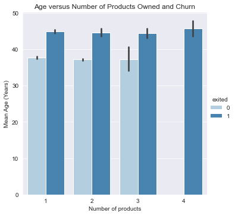

```python
sns.catplot(data=data, y='age', x='numofproducts',hue='exited', kind='bar', palette='Blues')
plt.xlabel('Number of products')
plt.ylabel('Mean Age (Years)')
plt.title('Age versus Number of Products Owned and Churn');
```

The average age for retained clients is on average between 35-40 for any number of products owned while the average age for churned clients is 45-50 years for any number of products owned. It is worth noting all clients with 4 products exited.